# Name-and-Birthdate Matching in Voter Purges

Two people who have never met, one match key, and a purge rule built on the assumption that such a thing cannot happen

Democracy’s Data

Last updated September 13, 2026 at 10:53a EDT

Somewhere in New Jersey there are two people who have never met. They live in different counties, with different families, different addresses, no connection of any kind. They also have the same first name, the same last name, and the same date of birth — not the same birthday, the same *date*, year included.

For roughly a decade, a consortium of states treated exactly this coincidence as evidence of **duplicate registration** — one person on two states’ lists — and used the matches to justify removing voters. Finding and removing such doubles is **deduplication**, and everyone who keeps a list does it; the question is the rule. Two records, same name, same birth date: same person, surely? That is the right question. It has an answer, and it is not the one intuition supplies.

## The test

The test has two parts: first, reproduce the actual matching rule on a real statewide file and count what it catches. The Interstate Crosscheck program, run by the Kansas Secretary of State’s office on behalf of a group of member states from about 2005 to 2019, flagged registrations sharing **a first name, a last name and a full date of birth** across its member states. New Jersey’s registration list is one of the few public files carrying the complete date of birth. So the exact key can be applied to 6,657,135 real records rather than approximated. Houston County, Georgia’s extract, 127,560 records with only a birth *year*, supplies the coarser key most states force on any matcher.

The second part is borrowed, because no public voter file can say whether a matched pair is one person or two. Goel, Meredith, Morse, Rothschild and Shirani-Mehr (2020) obtained Crosscheck’s own 2012 output for Iowa, the one state able to supply it.[^1] Those records carry a field no public file has: whether the last four digits of each registrant’s Social Security number matched. Their study grades the rule this brief counts; what a registration record is in the first place is the voter-file chapter’s subject.

## The data

Six columns are read from each of New Jersey’s 21 county extracts: first name, last name, middle name, date of birth, county and status. The other 22 columns, addresses included, are never loaded at all: a street address that is never read cannot leak. The six become one string per registrant — the **match key**, the thing two records must share, character for character, before a rule will call them the same person — and that string is the entire matching rule:

```
TAMMY|HALSTEAD|1975-05-11
```

Uppercase it, trim it, and a person has been reduced to a key. Two records whose keys are identical are an **exact match**. Sort 6,657,135 of those keys, count how often each repeats, and you have measured the Crosscheck program.

Four decisions shaped the counting. **Every record counts, whatever its status**: purges — removals from the registration list — act on the whole roll, and go after inactive records first. **Case and spacing are flattened before comparing**, which creates matches, rightly: a trailing space was never a fact about a person. **The middle name is cut to an initial**, because a file where some people wrote *Q* and some wrote *Quentin* cannot be compared on the full field.

And **nothing that identifies a person is kept**: this brief’s tables hold counts and distributions only, because a file of the colliding keys would be a purge list sitting in a teaching folder. Only 4 records in the whole state carry no date of birth, so nothing needed filling in. To *impute* a value is to fill in what nobody recorded by guessing it, and nothing here was imputed.

The tables that come out are small. `keys.csv` counts, for six versions of the key, the registrants `flagged` and the colliding `pairs`; `ga_keys.csv` does the same for Georgia. `groupsize.csv` counts how many registrants share each key. `monthday.csv` and `birthyears.csv` count registrations by calendar date and by birth year, `scaling.csv` counts collisions in random subsamples of the file, and `birthday.csv` holds the exact arithmetic of the next section.

That arithmetic starts in a room, not a file, with the puzzle statisticians call the **birthday problem**. Take 20 people and ask whether any two share a *birthday* — just the day, ignoring the year, with 365 to go around.

> **Before you read on, commit to two numbers.** In a room of 20 people, what is the probability that at least two of them share a birthday? And how many people would you need before a shared birthday is more likely than not? Write both down; most people answer the second somewhere between 100 and 200.

## What it says about democracy

The answers are 41.1% and 23 people.

People in the room: between 2 and 120 — the class has 20

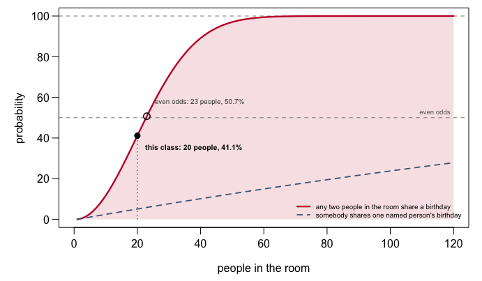

**Figure 1. The chance that a room of any given size contains a shared birthday.** A curve over room size, because the finding is how fast the chance climbs. The dashed line is the question people answer by mistake — the chance somebody shares *one named person’s* birthday, which at 20 people is only 5.1%.

The curve climbs so fast because it counts **pairs, not people**. The arithmetic runs person by person. The first can have any birthday. The chance that the second misses it is 364 in 365; the chance that the third misses both is 363 in 365; and so on down. Multiply the 19 fractions together and the chance that *nobody* in a room of 20 shares a birthday is 58.9%, so the chance that somebody does is the rest, 41.1%. Put the other way, a room of 20 holds 190 pairs, one chance of coincidence each. Add a person and you add a chance for every person already there: the people grow in a line and the pairs grow in a square. Everything else in this brief is that one fact applied to a bigger room.

Now swap the room for New Jersey’s file, and the birthday for a name plus full date of birth:

| Quantity | Value |
| --- | --- |
| Registration records | 6,657,135 |
| Distinct first+last+DOB keys | 6,653,955 |
| Keys held by more than one registrant | 3,149 |
| Registrants sharing a key with someone else | 6,329 |
| Colliding pairs | 3,212 |
| Largest group sharing one key | 4 |

**6,329 people in one state, 0.10% of the roll, share a first name, last name and full date of birth with at least one other registrant.** The groups are small: 3,119 pairs, 29 triples, one group of four. But 3,212 is not zero, and zero is what a purge rule assumes. Of the 3,149 colliding keys, 2,255 span two counties — pairs that look exactly like a person registered in two places, visible only when jurisdictions pool their lists.

The key’s precision is a dial:

Six rules applied to the same 6,657,135 New Jersey registration records.

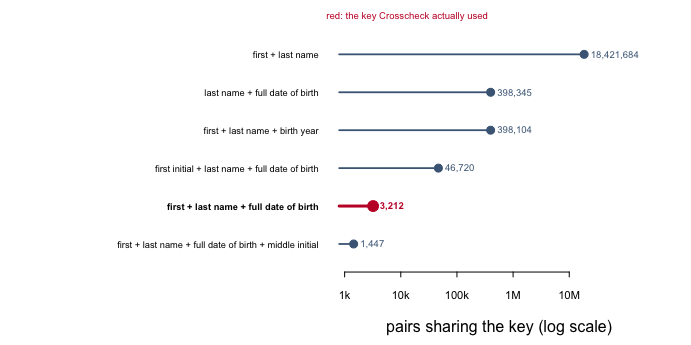

**Figure 2. The same 6,657,135 records, keyed six ways.** A ladder on a log axis, because the collision counts span four orders of magnitude and the finding is the distance between rungs: pairs of *different* records a rule would treat as one person.

Three findings fall out. **Birth year is not date of birth.** Matching on the year alone produces 124 times as many colliding pairs as the full date, and most states, Georgia included, publish only the year. Keyed that way, 0.75% of Houston County’s registrants collide. **Loosening the key is expensive**: cutting the first name to an initial — a **fuzzy** match, one that tolerates some difference between the records, so that Robert can match Bob — multiplies collisions by 15. **And the cheap fix was available**: a middle initial these records already carry removes 55% of the collisions.

The false-match rate — the rate of **false positives**, a rule saying *same person* when the truth is two — is not even a fixed property of a rule. Count the key’s collisions in random subsamples, and the rate grows with the pool. A county-sized pool of 332,857 records produces 3.1 colliding pairs per 100,000; the full state produces 48.2 — about 16 times the rate, from the identical rule, because the pairs grow in a square. A rule that is accurate in a county is not accurate in a state, and in 2012 Crosscheck ran across more than 45 million records.

One more thing sits under the key:

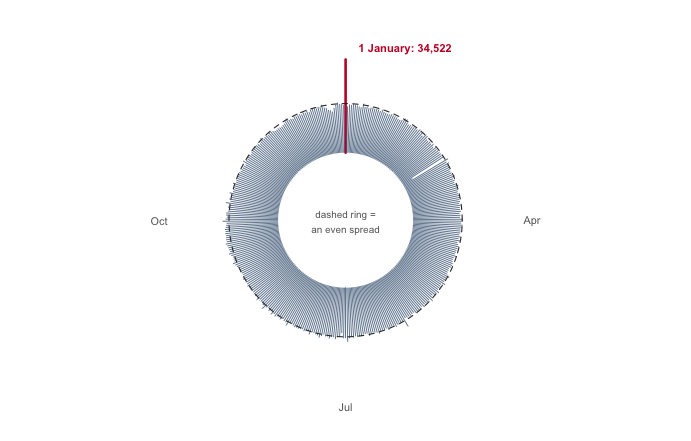

**Figure 3. Every calendar date, and the number of New Jersey registrants carrying it.** A year is a cycle, so it is drawn as one: 366 spokes, length proportional to count, with a dashed ring where an even spread would end. One spoke breaks the circle.

**34,522 registrants carry a date of birth of 1 January, 1.90 times the even-spread expectation.** That is not a fact about obstetrics. It is what a default value looks like: a field that had to be filled, filled with the first date available. A single sentinel, 1800-01-01, is carried by 13,282 records, and nobody born in 1800 is registered to vote in New Jersey.

Inside that group the date is the same for everyone, so it contributes nothing to the key. The rule quietly collapses to first-plus-last name, the top rung of Figure 2, and the consequence is measurable: 0.20% of the records produce 2.6% of the statewide collisions. **A matching rule fails worst on the records that were already the most damaged.** The national file behind the 2012 election was worse still: Goel and colleagues found 14% of its records carrying a first-of-the-month birthday, and deleted them before estimating anything.

So what did the matches turn out to be, where somebody could check? In Iowa’s copy of Crosscheck’s output, among the flagged pairings where both records’ Social Security digits were known, about 70-75% really were one person registered in two states: people who moved, which is not fraud. Of the 25,987 confirmed duplicates, exactly fewer than 10 were used to vote twice. And among the pairs that looked like double voting, the Social Security digits said 99.5% were **two different people**.

Now apply it as a purge rule, cancelling the older registration of every matched pair. The authors estimate that rule would impede about **approximately 300 legitimate votes for every double vote prevented**, against a national double-voting rate they put at one in 4,000 voters. The program was suspended in December 2019, in settlement of an ACLU of Kansas lawsuit over how carelessly the data had been handled as it moved between states, and has not run since.[^2]

## What this brief cannot tell you

**It cannot tell one person from two.** A name and a date of birth do not contain that information, which is the finding. Every claim above about which matches were real is Goel and colleagues’, made possible only by Social Security digits no public file carries.

**It is one state, plus one Georgia county.** The cross-county collisions inside New Jersey stand in for cross-state matching, but counties in one state share naming patterns and migration that thirty scattered states do not. No number here is a national false-positive rate, and none is offered as one.

**It cannot say the placeholder dates drove the problem.** The pile-up is real, and still a side effect: across all 366 dates the clustering adds only 0.5% to the collisions. The engine is the coarseness of the key and the size of the pool.

**And it cannot name anyone the rule wronged.** The counts say how many strangers share a key, not which flagged registration was cancelled or with what consequence.

## What you should have learned

- A shared birthday passes even odds at just 23 people, because coincidences count pairs: 20 people hold 190 of them, and pairs grow with the square of the people.
- The Crosscheck key flags 6,329 of New Jersey’s 6,657,135 registrants, 0.10% of the roll, as sharing a full name-and-birthdate key with a stranger.
- Key precision is everything: matching on birth year instead of the full date multiplies colliding pairs by 124, and a middle initial removes 55% of them.
- The same rule gets worse as the pool grows: 3.1 false-match pairs per 100,000 records in a county-sized pool, 48.2 in the full state.
- Where ground truth existed, 99.5% of apparent double votes were two different people, and the purge rule would have impeded about approximately 300 legitimate votes per double vote prevented.

## Extensions

None of these is answered above, and every one can be answered from the tables the Sources section hands over.

- `keys.csv` counts, in `flagged` and `pairs`, what six versions of the key catch. Compare its `pct` column rung by rung. Which single ingredient of the key does the most work?
- `ga_keys.csv` applies the same rules to a Georgia county. Compare its `pct` against New Jersey’s for the birth-year key. Does the coarse key behave the same in a far smaller pool?
- `groupsize.csv` counts colliding groups by `group_size` and `registrants`. How many unrelated people share the largest group’s key?
- `monthday.csv` counts registrants by `monthday`. Sort by `n`. What do the dates at the top of the list have in common?
- `scaling.csv` follows the collision rate in `per100k` as the pool in `n` grows. What happens to false matches per registrant when the roll doubles?

Two stretch ideas point past the spreadsheet. Find out whether your own state publishes a full date of birth or only a year, and work out from Figure 2 which rung of the ladder any matcher there is forced onto. And read Goel and colleagues’ account of the 2008 McDonald–Levitt double-voting estimate for New Jersey, which assumed uniform birthdays and overstated double voting by roughly a factor of ten.

## Sources

**Data**

- New Jersey statewide voter registration extract, `vlist_<County>.csv`, all 21 counties, consulted 11 August 2026. 6,657,135 registration records carrying first name, last name, middle name, suffix and full date of birth. Public records, but not posted for download: the Division of Elections releases the list on request, which is how this copy was obtained. https://www.nj.gov/state/elections/index.shtml
- Georgia Secretary of State, Houston County voter registration extract, consulted 11 August 2026. 127,560 registration records carrying first name, last name, middle name and **birth year only**. Public records; this copy arrived as working material in a county redistricting matter. https://sos.ga.gov/page/order-voter-registration-lists-and-files
- Neither file is redistributed with this brief. No name, date of birth or address from either appears above except the one illustrative key, and every figure and table is built from counts alone.

**Academic literature**

- Goel, S., Meredith, M., Morse, M., Rothschild, D. and Shirani-Mehr, H. (2020). “One Person, One Vote: Estimating the Prevalence of Double Voting in U.S. Presidential Elections.” *American Political Science Review* 114(2): 456–469. https://doi.org/10.1017/S000305541900087X — **every claim above about Crosscheck’s matches, the Social Security comparison, the 14% first-of-the-month finding and the approximately 300-to-one ratio is theirs.**
- McDonald, M. P. and Levitt, J. (2008). “Seeing Double Voting: An Extension of the Birthday Problem.” *Election Law Journal* 7(2): 111–122, doi:10.1089/elj.2008.7202 (the publisher refuses automated requests, so the address is given as text). On double voting in New Jersey in 2004; with McDonald, M. P. (2007), on placeholder dates of birth — both discussed above **as Goel et al. report them** rather than read directly.
- ACLU of Kansas. *Moore v. Kobach*, the lawsuit whose December 2019 settlement suspended Crosscheck. https://www.aclukansas.org/en/cases/moore-v-kobach

**The data itself**

Every figure above is drawn from these tables. They are plain CSV, they open in a spreadsheet, and they are yours to take further.

`birthday.csv`, `birthyears.csv`, `crosscounty.csv`, `ga_keys.csv`, `groupsize.csv`, `keys.csv`, `monthday.csv`, `scaling.csv`

One more file is not data about the subject – it is how this chapter checked its own numbers: `facts.csv`, the individual numbers the text above quotes.

[^1]: Sharad Goel, Marc Meredith, Michael Morse, David Rothschild and Houshmand Shirani-Mehr, “One Person, One Vote: Estimating the Prevalence of Double Voting in U.S. Presidential Elections,” *American Political Science Review* 114, no. 2 (2020): 456–469, https://doi.org/10.1017/S000305541900087X.
[^2]: *Moore v. Kobach*; the ACLU of Kansas’s account of the case and the settlement is at https://www.aclukansas.org/en/cases/moore-v-kobach.